# I do it for fun

Charles Kwame Appiah

2025-03-28

# Theme

“bootstrap”, “cerulean”, “cosmo”, “darkly”, “flatly”, “journal”, “lumen”, “paper”, “readable”, “sandstone”, “simplex”, “spacelab”, “united”, “yeti”

# Data Types

Data types are used to represent different types of data in R. R has several built-in data types, such as `numeric`, `character`, `integer`, `complex`, and `logical`. Data types are used to store different types of data, such as numbers, text, and logical values.

```r
x <- "Hello Charles, I hope you're working hard to become who you are destined to be by God's purpose? "
x
```

```
## [1] "Hello Charles, I hope you're working hard to become who you are destined to be by God's purpose? "
```

```r
class(x) # checking the class of variable x
```

```
## [1] "character"
```

```r
y <- pi^2 # calculating the square of pi
y
```

```
## [1] 9.869604
```

```r
class(y) # checking the class of variable y
```

```
## [1] "numeric"
```

```r
z <- 15L # assigning 15 to variable
z
```

```
## [1] 15
```

```r
class(z) # checking the class of variable z
```

```
## [1] "integer"
```

```r
a <- (5 + 2i)^2 # calculating the square of (5 + 2i)
a
```

```
## [1] 21+20i
```

```r
class(a) # checking the class of variable a
```

```
## [1] "complex"
```

```r
l <- TRUE # assigning TRUE to variable l
class(l) # checking the class of variable l
```

```
## [1] "logical"
```

```r
x <- list(age=c(10,21,22), weight=c(30,33,32)) # creating a list x
x
```

```
## $age
## [1] 10 21 22
##
## $weight
## [1] 30 33 32
```

```r
names(x) # Calling the names of the list x
```

```
## [1] "age"    "weight"
```

```r
length(x) # checking the length of the list x
```

```
## [1] 2
```

```r
kx <- data.frame(age=c(11,14,22), weight=c(30,33,32)) # creating a dataframe xk
kx
```

| age | weight |
| --- | --- |
| 11 | 30 |
| 14 | 33 |
| 22 | 32 |

# Vector and List

```r
d <- c("Charles Kwame Appiah is my name") # creating a vector
d
```

```
## [1] "Charles Kwame Appiah is my name"
```

```r
class(d) # checking the class of variable d
```

```
## [1] "character"
```

```r
length(d) # checking the length of variable d
```

```
## [1] 1
```

```r
nchar(d) # checking the number of characters in variable d
```

```
## [1] 31
```

```r
f<- c(1,3,4,6,7) # creating a vector
f
```

```
## [1] 1 3 4 6 7
```

```r
class(f) # checking the class of variable f
```

```
## [1] "numeric"
```

```r
fo<- c(1L,3L,4L,6L,7L) # creating a vector
fo
```

```
## [1] 1 3 4 6 7
```

```r
class(fo) # checking the class of variable fo
```

```
## [1] "integer"
```

# Vectors

Vectors can be created with the `c()` function. The `c()` function can take multiple arguments and combine them into a single vector. The `c()` function can also be used to combine multiple vectors into a single vector.

```r
# Initialization
x <- vector(mode = "logical", length = 5) # creating a vector with 5 logical elements
x
```

```
## [1] FALSE FALSE FALSE FALSE FALSE
```

```r
class(x)
```

```
## [1] "logical"
```

```r
x[1:3] <- TRUE # indexing the first to third element with TRUE
x
```

```
## [1]  TRUE  TRUE  TRUE FALSE FALSE
```

# Logical

Logical vectors are created with the `c()` function. Logical vectors can be used to store TRUE or FALSE values. Logical vectors are used in R to represent binary data.Binary data is data that can take on one of two values, such as TRUE or FALSE.

```r
s <- c(TRUE, FALSE,TRUE, 1) # creating a vector
s
```

```
## [1] 1 0 1 1
```

```r
as.logical(s) # converting the vector to logical
```

```
## [1]  TRUE FALSE  TRUE  TRUE
```

# List

List is a collection of multiple objects. The objects can be of different classes. Lists are created with the `list()` function

```r
q <- list("Hello World",2015L, TRUE, 32.1) # creating a list
q
```

```
## [[1]]
## [1] "Hello World"
##
## [[2]]
## [1] 2015
##
## [[3]]
## [1] TRUE
##
## [[4]]
## [1] 32.1
```

```r
class(q[[2]]) # Checking the class of list 2
```

```
## [1] "integer"
```

```r
class(q[[4]]) # Checking the class of list 4
```

```
## [1] "numeric"
```

```r
class(q[[1]]) # Checking the class of list 1
```

```
## [1] "character"
```

# Matrix

Matrix is a two-dimensional array. It is created with the `matrix()` function. The `matrix()` function takes a vector as input and reshapes it into a matrix. The `nrow` argument specifies the number of rows in the matrix, and the `ncol` argument specifies the number of columns in the matrix.

```r
mat <- c(2,4,5,7) # creating a vector
dim(mat) <- c(2,2) # creating a matrix with 2 rows and 2 columns
mat
```

```
##      [,1] [,2]
## [1,]    2    5
## [2,]    4    7
```

```r
mar = c(2,4,5,7,8,9) # creating a vector
dim(mar) <- c(3,2) # creating a matrix with 3 rows and 2 columns
mar
```

```
##      [,1] [,2]
## [1,]    2    7
## [2,]    4    8
## [3,]    5    9
```

```r
temp <- c(3,4,5,5.6,6,7) # creating a vector
mati <- matrix(temp, nrow = 2, ncol = 3,byrow = TRUE) # creating a matrix with 2 rows and 3 columns
mati
```

```
##      [,1] [,2] [,3]
## [1,]  3.0    4    5
## [2,]  5.6    6    7
```

```r
temp <- c(3,4,5,5.6,6,7, 8, 9, 10) # creating a vector
mato <- matrix(temp, nrow=3, ncol=3,byrow=TRUE) # creating a matrix with 3 rows and 3 columns
mato
```

```
##      [,1] [,2] [,3]
## [1,]  3.0    4    5
## [2,]  5.6    6    7
## [3,]  8.0    9   10
```

```r
# Default byrow = FALSE
temp <- c(3,4,5,5.6,6,7) # creating a vector
mati <- matrix(temp, nrow=2, ncol=3,byrow=FALSE) # creating a matrix with 2 rows and 3 columns
mati
```

```
##      [,1] [,2] [,3]
## [1,]    3  5.0    6
## [2,]    4  5.6    7
```

```r
t1 <- c(23, 55) # creating a vector
t2 <- c(34, 45) # creating a vector

# By rows
rbind(t1,t2) # binding them by their rows
```

```
##    [,1] [,2]
## t1   23   55
## t2   34   45
```

```r
t3 <- c(32, 50)
t4 <- c(43, 54)

# By columns
cbind(t3,t4) # binding them by their columns
```

```
##      t3 t4
## [1,] 32 43
## [2,] 50 54
```

# Factors and Nominal Data

Factors are used to represent categorical data in R. Factors are created with the `factor()` function. The `factor()` function takes a vector as input and converts it into a factor. Factors are used to represent nominal data, which is data that has no inherent order.

```r
factor <- c("Yes","No","No","Yes") # creating a vector
factor # use to encode vectors as factors
```

```
## [1] "Yes" "No"  "No"  "Yes"
```

```r
f <- factor(c("Yes","No","No","Yes"), levels= c("Yes","No")) # creating a factor
f
```

```
## [1] Yes No  No  Yes
## Levels: Yes No
```

# Missing Values

Missing values are represented by the `NA` value in R. The `is.na()` function can be used to check if a value is missing. The `is.na()` function returns `TRUE` if the value is missing and `FALSE` otherwise.

```r
x <- NA # Missing number
x
```

```
## [1] NA
```

```r
is.na(x) # checking if it is a missing number
```

```
## [1] TRUE
```

```r
u <- 0/0 # Missing number
u
```

```
## [1] NaN
```

```r
class(u) # checking for the class of variable u
```

```
## [1] "numeric"
```

# Dataframe

Data frames are used to store tabular data in R. Data frames are created with the `data.frame()` function. The `data.frame()` function takes vectors as input and combines them into a data frame. Data frames are used to store data in a structured format.

```r
c <- c("Charles","Richmond","Nicholas") # creating a vector
d <- c(12, 23, 45) # creating a vector
s <- c(FALSE,TRUE,TRUE) # creating a vector

dfr <- data.frame(Username = c,Age = d, Adult = s) # creating a dataframe
dfr
```

| Username | Age | Adult |
| --- | --- | --- |
| Charles | 12 | FALSE |
| Richmond | 23 | TRUE |
| Nicholas | 45 | TRUE |

```r
# First Row
dfr[1,] # accessing row 1 of the dataframe
```

|  | Username | Age | Adult |
| --- | --- | --- | --- |
| 1 | Charles | 12 | FALSE |

```r
# First Column
dfr[,1] # accessing column 1 [Username] of the dataframe
```

```
## [1] "Charles"  "Richmond" "Nicholas"
```

```r
# Age Column
dfr$Age
```

```
## [1] 12 23 45
```

```r
# Username Column
dfr$Username
```

```
## [1] "Charles"  "Richmond" "Nicholas"
```

```r
# Adult Column
dfr$Adult
```

```
## [1] FALSE  TRUE  TRUE
```

# Reading Data From File

Reading data from a file is a common task in data analysis. R provides functions to read data from various file formats, such as CSV, Excel, and text files. The `read.csv()` function is used to read data from a CSV file. The `read.csv()` function takes the path to the CSV file as input and returns a data frame. Sample data is provided in the `Training r.csv` file.

```r
### Importing Datasets
library(readxl) # Importing the readxl package
dat <- read.csv("C:/Users/HP/Desktop/Data Science/Machine learning/Training r.csv") # reading the dataset
#print(dat, na.rm = TRUE)
head(dat) # displaying the first few rows of the dataset
```

|  | itching | skin_rash | nodal_skin_eruptions | continuous_sneezing | shivering | chills | joint_pain | stomach_pain | acidity | ulcers_on_tongue | muscle_wasting | vomiting | burning_micturition | spotting_.urination | fatigue | weight_gain | anxiety | cold_hands_and_feets | mood_swings | weight_loss | restlessness | lethargy | patches_in_throat | irregular_sugar_level | cough | high_fever | sunken_eyes | breathlessness | sweating | … |
| --- | --- | --- | --- | --- | --- | --- | --- | --- | --- | --- | --- | --- | --- | --- | --- | --- | --- | --- | --- | --- | --- | --- | --- | --- | --- | --- | --- | --- | --- | --- |
| 1 | 1 | 1 | 1 | 0 | 0 | 0 | 0 | 0 | 0 | 0 | 0 | 0 | 0 | 0 | 0 | 0 | 0 | 0 | 0 | 0 | 0 | 0 | 0 | 0 | 0 | 0 | 0 | 0 | 0 | … |
| 2 | 0 | 1 | 1 | 0 | 0 | 0 | 0 | 0 | 0 | 0 | 0 | 0 | 0 | 0 | 0 | 0 | 0 | 0 | 0 | 0 | 0 | 0 | 0 | 0 | 0 | 0 | 0 | 0 | 0 | … |
| 3 | 1 | 0 | 1 | 0 | 0 | 0 | 0 | 0 | 0 | 0 | 0 | 0 | 0 | 0 | 0 | 0 | 0 | 0 | 0 | 0 | 0 | 0 | 0 | 0 | 0 | 0 | 0 | 0 | 0 | … |
| 4 | 1 | 1 | 0 | 0 | 0 | 0 | 0 | 0 | 0 | 0 | 0 | 0 | 0 | 0 | 0 | 0 | 0 | 0 | 0 | 0 | 0 | 0 | 0 | 0 | 0 | 0 | 0 | 0 | 0 | … |
| 5 | 1 | 1 | 1 | 0 | 0 | 0 | 0 | 0 | 0 | 0 | 0 | 0 | 0 | 0 | 0 | 0 | 0 | 0 | 0 | 0 | 0 | 0 | 0 | 0 | 0 | 0 | 0 | 0 | 0 | … |
| 6 | 0 | 1 | 1 | 0 | 0 | 0 | 0 | 0 | 0 | 0 | 0 | 0 | 0 | 0 | 0 | 0 | 0 | 0 | 0 | 0 | 0 | 0 | 0 | 0 | 0 | 0 | 0 | 0 | 0 | … |

```r
data <- read_xlsx("C:/Users/HP/Desktop/Data Science/Pandas/Copy of V1- UN Data on Refugees (AiCE __ Dataset).xlsx") # reading the dataset
 head(data) # displaying the first few rows of the dataset
```

| Country or territory of asylum or residence | Country or territory of origin | Year | Refugees* | Refugees assisted by UNHCR | Total refugees and people in refugee-like situations** | Total refugees and people in refugee-like situations assisted by UNHCR | Total Administrative Cost for Host Country |
| --- | --- | --- | --- | --- | --- | --- | --- |
| Afghanistan | Iran (Islamic Rep. of) | 2021 | 38 | 38 | 38 | 38 | 760000 |
| Afghanistan | Pakistan | 2021 | 72188 | 123 | 72188 | 123 | 1443760000 |
| Albania | China | 2021 | 14 | 0 | 14 | 0 | 280000 |
| Albania | Egypt | 2021 | 5 | 0 | 5 | 0 | 100000 |
| Albania | Iraq | 2021 | 5 | 0 | 5 | 0 | 100000 |
| Albania | Serbia and Kosovo: S/RES/1244 (1999) | 2021 | 57 | 0 | 57 | 0 | 1140000 |

# Sequence Creation

Sequence is a collection of numbers in a specific order. Sequences can be created in R using the `:` operator, the `seq()` function, and the `rep()` function. The `:` operator is used to create a sequence of numbers from a starting value to an ending value. The `seq()` function is used to create a sequence of numbers with a specified start, end, and step size. The `rep()` function is used to repeat a sequence of numbers a specified number of times.

```r
# Sequence
v <- (10:20) # creating a sequence
v # start from 10 and end at 20
```

```
##  [1] 10 11 12 13 14 15 16 17 18 19 20
```

```r
w <- (-5:9)
w # start from -5 and end at 9
```

```
##  [1] -5 -4 -3 -2 -1  0  1  2  3  4  5  6  7  8  9
```

```r
qw <- seq(2,34,2) # creating a sequence
qw # start from 2 and end at 34 with a moving step of 2
```

```
##  [1]  2  4  6  8 10 12 14 16 18 20 22 24 26 28 30 32 34
```

```r
iqw <- seq(2,34,length=6) # creating a sequence
iqw # start from  2 and end at 34 with a length of 6
```

```
## [1]  2.0  8.4 14.8 21.2 27.6 34.0
```

```r
repe <- rep(1:4,4) # creating a sequence
repe # repeat from 1 to 4, 4 times
```

```
##  [1] 1 2 3 4 1 2 3 4 1 2 3 4 1 2 3 4
```

```r
eq <- rep("Hello Ann", 5) # creating a sequence
eq # repeat from Hello Ann, 5 times
```

```
## [1] "Hello Ann" "Hello Ann" "Hello Ann" "Hello Ann" "Hello Ann"
```

```r
we <- seq(1,15, 2) # creating a sequence
we  # start from 1 and end at 15 with a step of 2
```

```
## [1]  1  3  5  7  9 11 13 15
```

```r
we[1:5] # slicing from index 1 to 5
```

```
## [1] 1 3 5 7 9
```

```r
class(we) # checking the class of we
```

```
## [1] "numeric"
```

```r
fo <- list("Hello","Hi","Hey") # creating a list
fo
```

```
## [[1]]
## [1] "Hello"
##
## [[2]]
## [1] "Hi"
##
## [[3]]
## [1] "Hey"
```

```r
fo[c(1,2)] # for several elements
```

```
## [[1]]
## [1] "Hello"
##
## [[2]]
## [1] "Hi"
```

```r
fo[c(1,2,3)] # for several elements
```

```
## [[1]]
## [1] "Hello"
##
## [[2]]
## [1] "Hi"
##
## [[3]]
## [1] "Hey"
```

```r
fo[[2]] # for only one element
```

```
## [1] "Hi"
```

```r
class(fo[[3]]) # checking the class of the third element
```

```
## [1] "character"
```

```r
wi <- list(age=c(12,23,45), height=c(12.3,45.4, 34.5)) # creating a list
wi
```

```
## $age
## [1] 12 23 45
##
## $height
## [1] 12.3 45.4 34.5
```

```r
class(wi) # checking the class of wi
```

```
## [1] "list"
```

```r
woo <- data.frame(age = c(12,23,45), height = c(12.3,45.4, 34.5)) # creating a dataframe
woo
```

| age | height |
| --- | --- |
| 12 | 12.3 |
| 23 | 45.4 |
| 45 | 34.5 |

```r
class(woo) # checking the class of woo
```

```
## [1] "data.frame"
```

```r
wi$age # accessing only the age list
```

```
## [1] 12 23 45
```

```r
wi$height # accessing only the height list
```

```
## [1] 12.3 45.4 34.5
```

```r
wi[["age"]] # accessing only the age list
```

```
## [1] 12 23 45
```

```r
wi[['h',exact = FALSE]] # partial matching
```

```
## [1] 12.3 45.4 34.5
```

```r
class(wi$age) # checking the class of age list
```

```
## [1] "numeric"
```

```r
class(wi$height) # checking the class of height list
```

```
## [1] "numeric"
```

```r
wr <- matrix(1:9, nrow = 3, ncol = 3, by = TRUE) # creating a matrix with 3 rows and 3 columns
wr # creating a matrix with 3 rows and 3 columns
```

```
##      [,1] [,2] [,3]
## [1,]    1    2    3
## [2,]    4    5    6
## [3,]    7    8    9
```

```r
class(wr) # checking the class of wr
```

```
## [1] "matrix" "array"
```

```r
class(wr[1,1]) # checking the class of row 1 column 1
```

```
## [1] "integer"
```

```r
class(wr[1,1, drop=FALSE]) # checking the class of row 1 column 1
```

```
## [1] "matrix" "array"
```

```r
ch <- c(1:9,NA,NA,NA) # creating a vector
ch
```

```
##  [1]  1  2  3  4  5  6  7  8  9 NA NA NA
```

```r
i<- is.na(ch) # checking for missing numbers
i
```

```
##  [1] FALSE FALSE FALSE FALSE FALSE FALSE FALSE FALSE FALSE  TRUE  TRUE  TRUE
```

```r
ch[!i] # removing missing numbers
```

```
## [1] 1 2 3 4 5 6 7 8 9
```

# Vectorization

Vectorization is a technique used in `R` to perform operations on vectors without using loops. Vectorization allows you to perform operations on vectors more efficiently than using loops. Vectorization is a key concept in `R` programming and is used to write efficient and concise code.

```r
### Vectorization
ew <- rnorm(1000) # creating a vector

er <- rnorm(1000) # creating a vector

cv <- vector(mode="numeric", length=1000) # creating a vector

### Iteration
start <- proc.time() # starting the timer
for (i in 1:1000){
cv[i] <- ew[i] + er[i] # adding the two vectors
}
proc.time()-start # initiating the timer
```

```
##    user  system elapsed
##    0.03    0.00    0.02
```

```r
start <- proc.time() # starting the timer
cv <- ew + er # adding the two vectors
proc.time()-start # # initiating the timer
```

```
##    user  system elapsed
##    0.02    0.00    0.00
```

# Control Structures

Control structures are used to control the flow of a program. Control structures allow you to execute different code blocks based on conditions. Control structures include if-else statements, for loops, while loops, and repeat loops.

```r
x <- 20 # assigning 20 to x

if (x < 0) {
print("Negative!") # checking if x is negative
}else if (x < 10) {
print("Positive, less than 10!") # checking if x is less than 10
}else {
print("Number greater than 10!") # checking if x is greater than 10
}
```

```
## [1] "Number greater than 10!"
```

```r
x <- -20
if (x < 0) {
print("Negative!") # checking if x is negative
}else if (x < 10) {
print("Positive, less than 10!") # checking if x is less than 10
}else {
print("Number greater than 10!") # checking if x is greater than 10
}
```

```
## [1] "Negative!"
```

```r
x <- 6 # assigning 6 to x
if (x < 0) {
print("Negative!") # checking if x is negative
}else if (x < 10) {
print("Positive, less than 10!") # checking if x is less than 10
}else {
print("Number greater than 10!") # checking if x is greater than 10
}
```

```
## [1] "Positive, less than 10!"
```

# For Loop

`For loop` is used to execute a block of code for a specified number of times. `For loops` are used when you know the number of iterations in advance. `For loops` are used to iterate over a sequence of values.

```r
for (i in 1:100){
cat(i)
cat(" ") # inserting spaces between the numbers
}
```

```
## 1 2 3 4 5 6 7 8 9 10 11 12 13 14 15 16 17 18 19 20 21 22 23 24 25 26 27 28 29 30 31 32 33 34 35 36 37 38 39 40 41 42 43 44 45 46 47 48 49 50 51 52 53 54 55 56 57 58 59 60 61 62 63 64 65 66 67 68 69 70 71 72 73 74 75 76 77 78 79 80 81 82 83 84 85 86 87 88 89 90 91 92 93 94 95 96 97 98 99 100
```

```r
letters # lower case
```

```
##  [1] "a" "b" "c" "d" "e" "f" "g" "h" "i" "j" "k" "l" "m" "n" "o" "p" "q" "r" "s"
## [20] "t" "u" "v" "w" "x" "y" "z"
```

```r
LETTERS # upper case
```

```
##  [1] "A" "B" "C" "D" "E" "F" "G" "H" "I" "J" "K" "L" "M" "N" "O" "P" "Q" "R" "S"
## [20] "T" "U" "V" "W" "X" "Y" "Z"
```

```r
class(letters) #
```

```
## [1] "character"
```

```r
for (x in letters){
cat(x)
cat(" ") # inserting spaces between the letters
}
```

```
## a b c d e f g h i j k l m n o p q r s t u v w x y z
```

# While loop

`While loops` are used to execute a block of code as long as a condition is true. `While loops` are used when you do not know the number of iterations in advance. `While loops` are used to execute a block of code as long as a condition is true. `While loops` are used when you do not know the number of iterations in advance.

```r
x <- -1 # assigning -1 to x
while (x < 5){
print(x) #
x <- x+1
}
```

```
## [1] -1
## [1] 0
## [1] 1
## [1] 2
## [1] 3
## [1] 4
```

```r
x<- 1
repeat{
print(x)
if (x > 7){
break
}
x <- x+1
}
```

```
## [1] 1
## [1] 2
## [1] 3
## [1] 4
## [1] 5
## [1] 6
## [1] 7
## [1] 8
```

```r
for (i in 1:100){
# Over ride the first 20 iterations
if (i <= 20){
next
}
}

# Functions
myPrinter <- function(x){
  for (i in seq(x)){
       print("Hello, Charles")
  }
}
myPrinter(3)
```

```
## [1] "Hello, Charles"
## [1] "Hello, Charles"
## [1] "Hello, Charles"
```

```r
volume <- function(x=3, y=3, z=3){
  print(x*y*z)
}
volume(y=3,z=5,x=11)
```

```
## [1] 165
```

```r
volume()
```

```
## [1] 27
```

```r
myPrinter <- function(..., mes){
print(sum(...))
print(mes)
}
myPrinter (3, 5, 11, mes= "Hi! Richmond")
```

```
## [1] 19
## [1] "Hi! Richmond"
```

```r
#ls() ### displaying objects stored in R currently
```

# Iterated Functions

Iterated function systems (IFS) are a method of constructing fractals; the resulting fractals are often self-similar. IFS fractals are more related to set theory than fractal geometry. They were introduced in 1988 by Michael Barnsley using the concept of affine transformations.

## lapply

lapply is used to apply a function to each element of a list. lapply returns a list of the same length as the input list, where each element is the result of applying the function to the corresponding element of the input list.

```r
# lapply
str(lapply)
```

```
## function (X, FUN, ...)
```

```r
x <- list(a=rnorm(10), b=rnorm(20), c=rnorm(30))
lapply(x, mean) # checking the mean of x
```

```
## $a
## [1] -0.3275779
##
## $b
## [1] -0.2826252
##
## $c
## [1] 0.1173755
```

```r
lapply(x, var)# checking the variance of x
```

```
## $a
## [1] 1.843443
##
## $b
## [1] 0.6898497
##
## $c
## [1] 1.311391
```

```r
lapply(x, sd) # checking the standard deviation of x
```

```
## $a
## [1] 1.357734
##
## $b
## [1] 0.8305719
##
## $c
## [1] 1.14516
```

## sapply

sapply is used to apply a function to each element of a list and simplify the result. sapply returns a vector or matrix instead of a list.

```r
# sapply
str(sapply) # checking the structure of sapply
```

```
## function (X, FUN, ..., simplify = TRUE, USE.NAMES = TRUE)
```

```r
xi <- list(a=rnorm(10), b=rnorm(20), c=rnorm(30))
sapply(xi, mean) # checking the mean of xi
```

```
##           a           b           c
##  0.06259375  0.68198028 -0.03325201
```

```r
sapply(xi, var) # checking the variance of xi
```

```
##         a         b         c
## 0.4756218 1.0297347 1.3061508
```

```r
sapply(xi, sd) # checking the standard deviation of xi
```

```
##         a         b         c
## 0.6896534 1.0147584 1.1428695
```

## Split

split is used to split a data frame or vector into groups. split returns a list of vectors, where each vector contains the elements of the input data frame or vector that belong to a particular group.

```r
# Split
dat <- data.frame(subject = 1:6,age = c(15, 17, 16,20,21,23),
adult = c(FALSE,FALSE,FALSE,TRUE,TRUE,TRUE))
s <- split(dat, dat$adult)
s # split them according to True and False
```

```
## $`FALSE`
##   subject age adult
## 1       1  15 FALSE
## 2       2  17 FALSE
## 3       3  16 FALSE
##
## $`TRUE`
##   subject age adult
## 4       4  20  TRUE
## 5       5  21  TRUE
## 6       6  23  TRUE
```

```r
sapply(s, function(x){
mean(x[["age"]])
})
```

```
##    FALSE     TRUE
## 16.00000 21.33333
```

```r
sapply(s, function(x){
var(x[["age"]])
})
```

```
##    FALSE     TRUE
## 1.000000 2.333333
```

```r
sapply(s, function(x){
sd(x[["age"]])
})
```

```
##    FALSE     TRUE
## 1.000000 1.527525
```

## tapply

tapply is used to apply a function to each group of a vector. tapply returns a vector or matrix, where each element is the result of applying the function to the corresponding group of the input vector.

```r
# tapply
str(tapply)
```

```
## function (X, INDEX, FUN = NULL, ..., default = NA, simplify = TRUE)
```

```r
x <- c(rnorm(10),rnorm(10),rnorm(10),rnorm(10))
f <- gl(4, 10)
f
```

```
##  [1] 1 1 1 1 1 1 1 1 1 1 2 2 2 2 2 2 2 2 2 2 3 3 3 3 3 3 3 3 3 3 4 4 4 4 4 4 4 4
## [39] 4 4
## Levels: 1 2 3 4
```

```r
tapply(x, f, mean)
```

```
##           1           2           3           4
##  0.19378925  0.11666294  0.01242451 -0.02501727
```

```r
tapply(x, f, var)
```

```
##         1         2         3         4
## 0.2228392 1.3075557 0.6513679 1.6748855
```

```r
tapply(x, f, sd)
```

```
##         1         2         3         4
## 0.4720584 1.1434840 0.8070737 1.2941737
```

```r
### Help
#?c
#?vector
#?sapply
#?lapply
#?tapply
```

# Types, Quality and Data preprocessing

Types, quality and data preprocessing are important steps in data analysis. Types refer to the data types of the variables in the dataset. Quality refers to the quality of the data, such as missing values and outliers. Data preprocessing refers to the steps taken to clean and prepare the data for analysis.

```r
wi
```

```
## $age
## [1] 12 23 45
##
## $height
## [1] 12.3 45.4 34.5
```

```r
# finding each column maximum
m <- sapply(wi,max)
m
```

```
##    age height
##   45.0   45.4
```

```r
# finding each column minimum
n <- sapply(wi,min)
n
```

```
##    age height
##   12.0   12.3
```

# Regularization

```r
# Regularization ith range [0,1]
wi$age <- ( (wi$age - n[1])/(m[1] - n[1]))*(1 - 0) + 0
wi$height <- ( (wi$height - n[2])/(m[2] - n[2]))*(1 - 0)

wi
```

```
## $age
## [1] 0.0000000 0.3333333 1.0000000
##
## $height
## [1] 0.0000000 1.0000000 0.6706949
```

# DPLYR AND TIDYR PACKAGES

`Dplyr` is a package for data manipulation in R. `Dplyr` provides a set of functions for manipulating data frames, such as selecting columns, filtering rows, and summarizing data. `Tidyr` is a package for data tidying in R. `Tidyr` provides functions for reshaping data frames, such as gathering columns into rows and spreading rows into columns.

```r
library(dplyr) # Importing the dplyr package
data(airquality) # loading the airquality dataset
class(airquality) # checking the class of airquality
```

```
## [1] "data.frame"
```

```r
airquality <- tibble(airquality) # converting airquality to a tibble
class(airquality) # checking the class of airquality
```

```
## [1] "tbl_df"     "tbl"        "data.frame"
```

```r
airquality # displaying the airquality dataset
```

| Ozone | Solar.R | Wind | Temp | Month | Day |
| --- | --- | --- | --- | --- | --- |
| 41 | 190 | 7.4 | 67 | 5 | 1 |
| 36 | 118 | 8.0 | 72 | 5 | 2 |
| 12 | 149 | 12.6 | 74 | 5 | 3 |
| 18 | 313 | 11.5 | 62 | 5 | 4 |
| NA | NA | 14.3 | 56 | 5 | 5 |
| 28 | NA | 14.9 | 66 | 5 | 6 |
| 23 | 299 | 8.6 | 65 | 5 | 7 |
| 19 | 99 | 13.8 | 59 | 5 | 8 |
| 8 | 19 | 20.1 | 61 | 5 | 9 |
| NA | 194 | 8.6 | 69 | 5 | 10 |

[output cut: 143 more lines]

```r
select(airquality, Ozone, Solar.R, Day) # selecting the Ozone, Solar.R and Day columns
```

| Ozone | Solar.R | Day |
| --- | --- | --- |
| 41 | 190 | 1 |
| 36 | 118 | 2 |
| 12 | 149 | 3 |
| 18 | 313 | 4 |
| NA | NA | 5 |
| 28 | NA | 6 |
| 23 | 299 | 7 |
| 19 | 99 | 8 |
| 8 | 19 | 9 |
| NA | 194 | 10 |

[output cut: 143 more lines]

```r
select(airquality, -(Wind:Month)) # offsetting Wind and Month from the airquality dataset
```

| Ozone | Solar.R | Day |
| --- | --- | --- |
| 41 | 190 | 1 |
| 36 | 118 | 2 |
| 12 | 149 | 3 |
| 18 | 313 | 4 |
| NA | NA | 5 |
| 28 | NA | 6 |
| 23 | 299 | 7 |
| 19 | 99 | 8 |
| 8 | 19 | 9 |
| NA | 194 | 10 |

[output cut: 143 more lines]

```r
filter(airquality, Month > 5, Month < 9, Day < 3) # values in Month greater than 5 and less than 9, Day values less than 3
```

| Ozone | Solar.R | Wind | Temp | Month | Day |
| --- | --- | --- | --- | --- | --- |
| NA | 286 | 8.6 | 78 | 6 | 1 |
| NA | 287 | 9.7 | 74 | 6 | 2 |
| 135 | 269 | 4.1 | 84 | 7 | 1 |
| 49 | 248 | 9.2 | 85 | 7 | 2 |
| 39 | 83 | 6.9 | 81 | 8 | 1 |
| 9 | 24 | 13.8 | 81 | 8 | 2 |

```r
filter(airquality, Day==1 | Day == 2) # Values of Day = 1 or 2
```

| Ozone | Solar.R | Wind | Temp | Month | Day |
| --- | --- | --- | --- | --- | --- |
| 41 | 190 | 7.4 | 67 | 5 | 1 |
| 36 | 118 | 8.0 | 72 | 5 | 2 |
| NA | 286 | 8.6 | 78 | 6 | 1 |
| NA | 287 | 9.7 | 74 | 6 | 2 |
| 135 | 269 | 4.1 | 84 | 7 | 1 |
| 49 | 248 | 9.2 | 85 | 7 | 2 |
| 39 | 83 | 6.9 | 81 | 8 | 1 |
| 9 | 24 | 13.8 | 81 | 8 | 2 |
| 96 | 167 | 6.9 | 91 | 9 | 1 |
| 78 | 197 | 5.1 | 92 | 9 | 2 |

```r
arrange(airquality,Ozone, desc(Solar.R))
```

| Ozone | Solar.R | Wind | Temp | Month | Day |
| --- | --- | --- | --- | --- | --- |
| 1 | 8 | 9.7 | 59 | 5 | 21 |
| 4 | 25 | 9.7 | 61 | 5 | 23 |
| 6 | 78 | 18.4 | 57 | 5 | 18 |
| 7 | 49 | 10.3 | 69 | 9 | 24 |
| 7 | 48 | 14.3 | 80 | 7 | 15 |
| 7 | NA | 6.9 | 74 | 5 | 11 |
| 8 | 19 | 20.1 | 61 | 5 | 9 |
| 9 | 36 | 14.3 | 72 | 8 | 22 |
| 9 | 24 | 13.8 | 81 | 8 | 2 |
| 9 | 24 | 10.9 | 71 | 9 | 14 |

[output cut: 143 more lines]

```r
mutate(airquality, Temp.C = round((Temp - 32) * 5/9)) # creating a new column for Temp.C
```

| Ozone | Solar.R | Wind | Temp | Month | Day | Temp.C |
| --- | --- | --- | --- | --- | --- | --- |
| 41 | 190 | 7.4 | 67 | 5 | 1 | 19 |
| 36 | 118 | 8.0 | 72 | 5 | 2 | 22 |
| 12 | 149 | 12.6 | 74 | 5 | 3 | 23 |
| 18 | 313 | 11.5 | 62 | 5 | 4 | 17 |
| NA | NA | 14.3 | 56 | 5 | 5 | 13 |
| 28 | NA | 14.9 | 66 | 5 | 6 | 19 |
| 23 | 299 | 8.6 | 65 | 5 | 7 | 18 |
| 19 | 99 | 13.8 | 59 | 5 | 8 | 15 |
| 8 | 19 | 20.1 | 61 | 5 | 9 | 16 |
| NA | 194 | 8.6 | 69 | 5 | 10 | 21 |

[output cut: 143 more lines]

```r
# Removing rows with missing values on the Ozone and Solar.R features
airquality <- filter(airquality, !is.na(Ozone),!is.na(Solar.R))
airquality
```

| Ozone | Solar.R | Wind | Temp | Month | Day |
| --- | --- | --- | --- | --- | --- |
| 41 | 190 | 7.4 | 67 | 5 | 1 |
| 36 | 118 | 8.0 | 72 | 5 | 2 |
| 12 | 149 | 12.6 | 74 | 5 | 3 |
| 18 | 313 | 11.5 | 62 | 5 | 4 |
| 23 | 299 | 8.6 | 65 | 5 | 7 |
| 19 | 99 | 13.8 | 59 | 5 | 8 |
| 8 | 19 | 20.1 | 61 | 5 | 9 |
| 16 | 256 | 9.7 | 69 | 5 | 12 |
| 11 | 290 | 9.2 | 66 | 5 | 13 |
| 14 | 274 | 10.9 | 68 | 5 | 14 |

[output cut: 101 more lines]

```r
### print(airquality, n=143)
```

```r
# grouping by month
by_month <- group_by (airquality, Month)
by_month
```

| Ozone | Solar.R | Wind | Temp | Month | Day |
| --- | --- | --- | --- | --- | --- |
| 41 | 190 | 7.4 | 67 | 5 | 1 |
| 36 | 118 | 8.0 | 72 | 5 | 2 |
| 12 | 149 | 12.6 | 74 | 5 | 3 |
| 18 | 313 | 11.5 | 62 | 5 | 4 |
| 23 | 299 | 8.6 | 65 | 5 | 7 |
| 19 | 99 | 13.8 | 59 | 5 | 8 |
| 8 | 19 | 20.1 | 61 | 5 | 9 |
| 16 | 256 | 9.7 | 69 | 5 | 12 |
| 11 | 290 | 9.2 | 66 | 5 | 13 |
| 14 | 274 | 10.9 | 68 | 5 | 14 |

[output cut: 101 more lines]

```r
# Finding the minimum, average and maximum value per Month
summarize (by_month, min(Ozone), mean(Ozone), max(Ozone))
```

| Month | min(Ozone) | mean(Ozone) | max(Ozone) |
| --- | --- | --- | --- |
| 5 | 1 | 24.12500 | 115 |
| 6 | 12 | 29.44444 | 71 |
| 7 | 7 | 59.11538 | 135 |
| 8 | 9 | 60.00000 | 168 |
| 9 | 7 | 31.44828 | 96 |

```r
#install.packages ("tidyr") #library (tidyr)

#dat #gather(dat, sex, count, -subject)

#dat \<- gather(dat, sex, class, count, -subject) #dat

#dat #separate(dat, sex, class, c("sex", "class"))

#dat #dat \<- gather(dat, lesson, grade, lesson1:lesson4, na.rm = TRUE)
#dat

#dat \<- spread(dat, quarter, grade) #dat

#mutate(dat, lesson = extract_numeric(lesson))
```

# Statistical Summary and Visualization

`Statistical summary and visualization` are important steps in data analysis. Statistical summary provides a summary of the data, such as the mean, median, and standard deviation. Visualization provides a visual representation of the data, such as bar charts and histograms.

```r
# Mean
internet_usage = c(22,0, 7,12,5, 33, 14, 8, 0, 9)

#internet_usage
mean(internet_usage) # finding the mean of internet_usage
```

```
## [1] 11
```

```r
net_usage = c(22,0,7,12,5,NA,33,14,8,NA,0,9)

# net_usage
mean(na.omit(net_usage)) # finding the mean of net_usage with missing numbers
```

```
## [1] 11
```

```r
# Median
median(net_usage, na.rm = TRUE)
```

```
## [1] 8.5
```

```r
# Minimum, Maximum and Range
A = c(49,33,63,48,54,62,52,64,71,68)
min(A)
```

```
## [1] 33
```

```r
max(A)
```

```
## [1] 71
```

```r
which.min(A)
```

```
## [1] 2
```

```r
which.max(A)
```

```
## [1] 9
```

```r
print(max(A) - min(A))
```

```
## [1] 38
```

```r
range(A)
```

```
## [1] 33 71
```

```r
print(range(A)[2] - range(A)[1])
```

```
## [1] 38
```

```r
summary(A)
```

```
##    Min. 1st Qu.  Median    Mean 3rd Qu.    Max.
##   33.00   49.75   58.00   56.40   63.75   71.00
```

# Percentile Values

Percentile values are used to divide a dataset into equal parts. The `quantile()` function is used to calculate percentile values in R. The `quantile()` function takes a vector as input and returns the percentile value for the specified quantile.

```r
X = c(3,4,5,6,7,8,10,10,11,12,14,14,14,15,16,17,21,25,27,32)
quantile(X,0.80)
```

```
##  80%
## 17.8
```

```r
quantile(X,0.50,type = 7)
```

```
## 50%
##  13
```

```r
quantile(X,0.25,type = 7)
```

```
##  25%
## 7.75
```

```r
quantile(X,0.75,type = 7)
```

```
##   75%
## 16.25
```

```r
median(X)
```

```
## [1] 13
```

```r
summary(X)
```

```
##    Min. 1st Qu.  Median    Mean 3rd Qu.    Max.
##    3.00    7.75   13.00   13.55   16.25   32.00
```

```r
sd(X)
```

```
## [1] 7.843703
```

```r
# cv(X)
```

## Interquartile Range

The interquartile range (IQR) is a measure of statistical dispersion, or how spread out the values in a dataset are. The IQR is calculated as the difference between the 75th percentile (Q3) and the 25th percentile (Q1) of the dataset. The IQR is used to identify outliers in a dataset.

```r
# Interquartile Range
irq = function(X) (quantile(X,0.75) - quantile(X,0.25))
irq(X)
```

```
## 75%
## 8.5
```

## Variance and Standard Deviation

Variance and standard deviation are measures of statistical dispersion. Variance is the average of the squared differences between each value in the dataset and the mean of the dataset. Standard deviation is the square root of the variance. Variance and standard deviation are used to measure the spread of the values in a dataset.

```r
# Variance and Standard Deviation
course = c(6, 2, 1, 9, 17, 4, 3, 2, 1, 5, 11 ,4, 3, 1, 2, 2, 5, 4, 3, 6)
1 / course
```

```
##  [1] 0.16666667 0.50000000 1.00000000 0.11111111 0.05882353 0.25000000
##  [7] 0.33333333 0.50000000 1.00000000 0.20000000 0.09090909 0.25000000
## [13] 0.33333333 1.00000000 0.50000000 0.50000000 0.20000000 0.25000000
## [19] 0.33333333 0.16666667
```

```r
cf = c(course, 0, course)
cf
```

```
##  [1]  6  2  1  9 17  4  3  2  1  5 11  4  3  1  2  2  5  4  3  6  0  6  2  1  9
## [26] 17  4  3  2  1  5 11  4  3  1  2  2  5  4  3  6
```

```r
vw <- 2 * course + cf + 1
vw
```

```
##  [1] 19  7  4 28 52 13 10  7  4 16 34 13 10  4  7  7 16 13 10 19 13 11  5 20 44
## [26] 26 11  8  5 12 28 20 11  6  6  7 13 14 11 16 19
```

```r
var(course)
```

```
## [1] 15.41842
```

```r
sum((course - mean(course)) ^ 2 / (length(course) - 1))
```

```
## [1] 15.41842
```

```r
sd(course)
```

```
## [1] 3.92663
```

```r
sqrt(var(course))
```

```
## [1] 3.92663
```

```r
std = function(x) sqrt(var(x))
std(course)
```

```
## [1] 3.92663
```

```r
sqrt(course)
```

```
##  [1] 2.449490 1.414214 1.000000 3.000000 4.123106 2.000000 1.732051 1.414214
##  [9] 1.000000 2.236068 3.316625 2.000000 1.732051 1.000000 1.414214 1.414214
## [17] 2.236068 2.000000 1.732051 2.449490
```

```r
sum(course)
```

```
## [1] 91
```

```r
prod(course)
```

```
## [1] 41878425600
```

```r
sort(course)
```

```
##  [1]  1  1  1  2  2  2  2  3  3  3  4  4  4  5  5  6  6  9 11 17
```

```r
order(course)
```

```
##  [1]  3  9 14  2  8 15 16  7 13 19  6 12 18 10 17  1 20  4 11  5
```

```r
sqrt(-14 + 9i)
```

```
## [1] 1.149634+3.914289i
```

## Coefficient of Variation

The coefficient of variation (CV) is a measure of relative variability. The CV is calculated as the standard deviation divided by the mean of the dataset. The CV is used to compare the variability of datasets with different units of measurement.

```r
cv = function(x) ( sd(x) / mean(x) )
cv(course)
```

```
## [1] 0.8629955
```

# Visualization of Qualitative Data

`Visualization of qualitative data` is an important step in data analysis. Qualitative data is data that is categorical or non-numeric. Visualization of qualitative data can help identify patterns and trends in the data. Bar charts, pie charts, and contingency matrices are commonly used to visualize qualitative data.

```r
mo = c("car","car","bus", "metro","metro","car","metro","metro","foot","car","foot","bus","bus","metro","metro","car","car","car","metro","car") # dataset of employee's
mo
```

```
##  [1] "car"   "car"   "bus"   "metro" "metro" "car"   "metro" "metro" "foot"
## [10] "car"   "foot"  "bus"   "bus"   "metro" "metro" "car"   "car"   "car"
## [19] "metro" "car"
```

```r
table(mo) # creating a table of mo
```

```
## mo
##   bus   car  foot metro
##     3     8     2     7
```

```r
prop.table(table(mo)) # creating a table of mo
```

```
## mo
##   bus   car  foot metro
##  0.15  0.40  0.10  0.35
```

```r
data.frame(mo)# creating a dataframe of mo
```

| mo |
| --- |
| car |
| car |
| bus |
| metro |
| metro |
| car |
| metro |
| metro |
| foot |
| car |

[output cut: 10 more lines]

## Bar Charts

`Bar charts` are used to visualize the frequency of categorical data. Bar charts are used to compare the frequency of different categories in a dataset. Bar charts are used to visualize the distribution of categorical data.

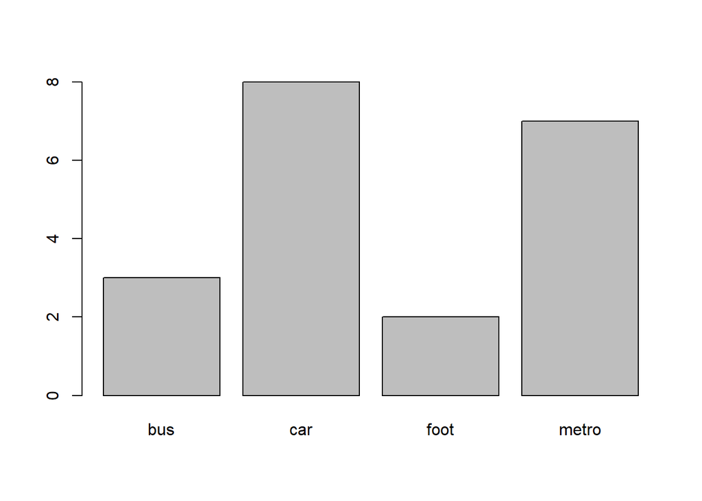

```r
barplot(table(mo)) # creating a bar chart of mo
```

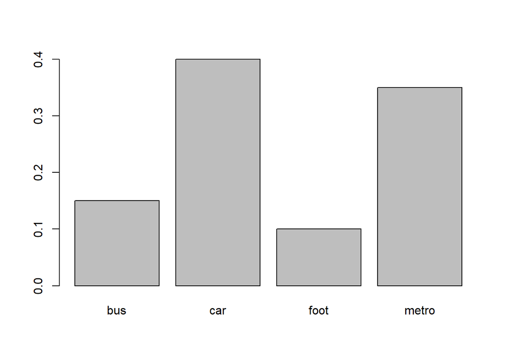

```r
barplot(prop.table(table(mo))) # creating a bar chart of mo
```

## Pie Chart

`Pie charts` are used to visualize the proportion of different categories in a dataset. Pie charts are used to compare the proportion of different categories in a dataset. Pie charts are used to visualize the distribution of categorical data.

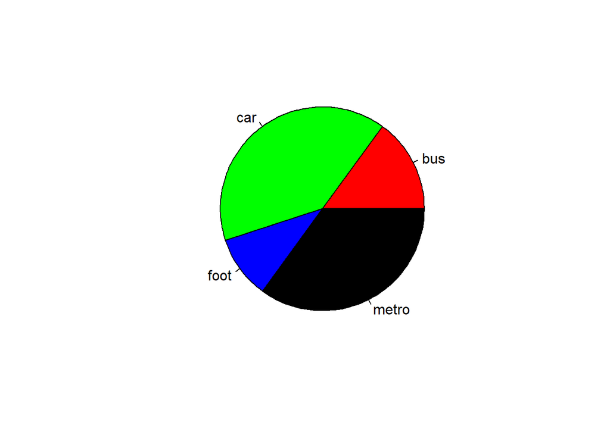

```r
pie(table(mo), col = c ("red", "green", "blue", "black")) # creating a pie chart of mo
```

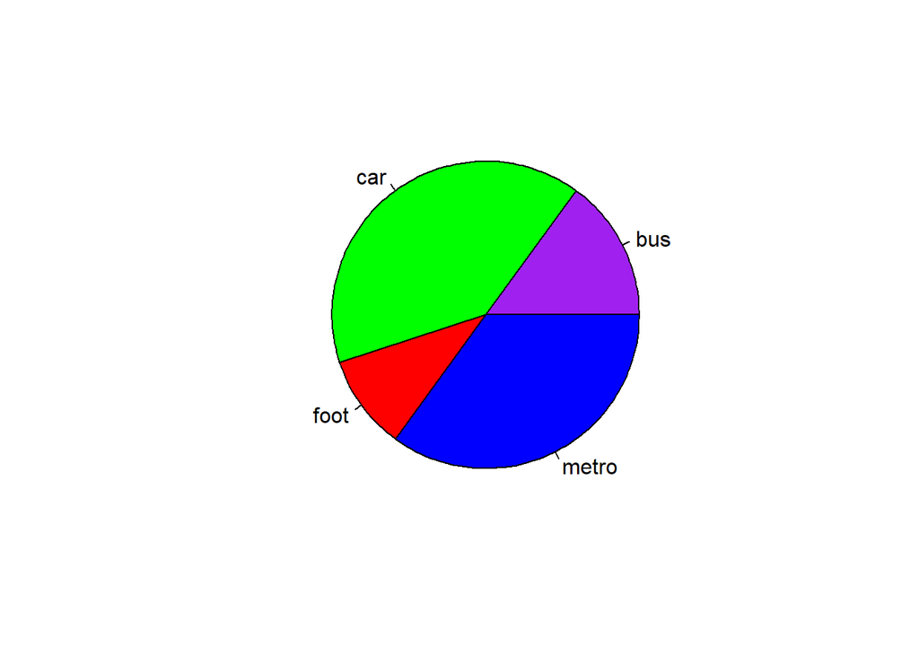

```r
pie(prop.table(table(mo)), col = c("purple", "green", "red", "blue")) # creating a pie chart of mo
```

# Contingency Matrix

`A contingency matrix` is used to visualize the relationship between two categorical variables. A contingency matrix is a two-dimensional table that shows the frequency of each combination of categories in the two variables. A contingency matrix is used to visualize the relationship between two categorical variables.

```r
g = c(rep("Male",8), rep("Female",12)) # creating a vector
g
```

```
##  [1] "Male"   "Male"   "Male"   "Male"   "Male"   "Male"   "Male"   "Male"
##  [9] "Female" "Female" "Female" "Female" "Female" "Female" "Female" "Female"
## [17] "Female" "Female" "Female" "Female"
```

```r
mg = table(mo,g) # creating a contingency matrix of mo and g
mg
```

```
##        g
## mo      Female Male
##   bus        2    1
##   car        5    3
##   foot       2    0
##   metro      3    4
```

```r
gm = data.frame(mo,g) # creating a dataframe of mo and g
gm
```

| mo | g |
| --- | --- |
| car | Male |
| car | Male |
| bus | Male |
| metro | Male |
| metro | Male |
| car | Male |
| metro | Male |
| metro | Male |
| foot | Female |
| car | Female |

[output cut: 10 more lines]

```r
margin.table(mg, 1) # creating a margin table of mg
```

```
## mo
##   bus   car  foot metro
##     3     8     2     7
```

```r
margin.table(mg,2) # creating a margin table of mg
```

```
## g
## Female   Male
##     12      8
```

```r
prop.table(mg)     # creating a table of mg
```

```
##        g
## mo      Female Male
##   bus     0.10 0.05
##   car     0.25 0.15
##   foot    0.10 0.00
##   metro   0.15 0.20
```

```r
prop.table(mg,1)   # creating a table of mg
```

```
##        g
## mo         Female      Male
##   bus   0.6666667 0.3333333
##   car   0.6250000 0.3750000
##   foot  1.0000000 0.0000000
##   metro 0.4285714 0.5714286
```

```r
prop.table(mg,2)   # creating a table of mg
```

```
##        g
## mo         Female      Male
##   bus   0.1666667 0.1250000
##   car   0.4166667 0.3750000
##   foot  0.1666667 0.0000000
##   metro 0.2500000 0.5000000
```

## Stacked Bar Charts and Grouped Bar Charts

`Stacked bar charts` are used to visualize the relationship between two categorical variables. Stacked bar charts are used to compare the frequency of different categories in one variable for each category in another variable. Stacked bar charts are used to visualize the relationship between two categorical variables.

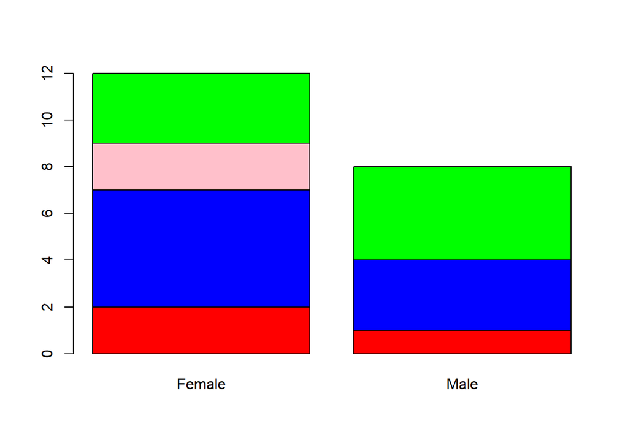

```r
barplot(mg, col = c("red","blue", "pink","green")) # creating a bar chart of mg
```

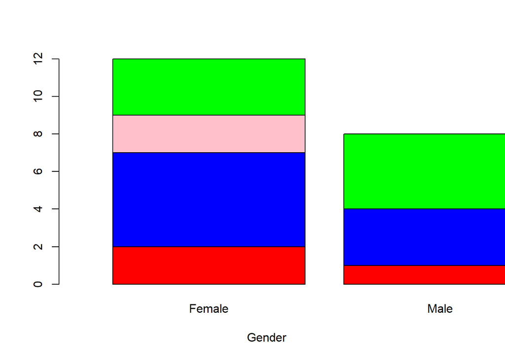

```r
barplot(mg,xlim=c(0,2), xlab="Gender", length=levels(mo), col = c("red","blue", "pink","green")) # creating a bar chart of mg
```

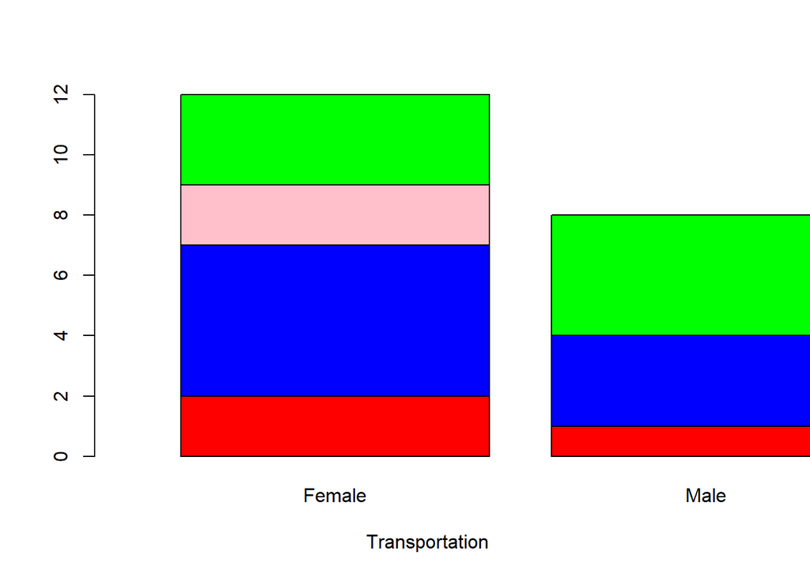

```r
barplot(mg,xlim=c(0,2), xlab="Transportation", length=levels(g), col = c("red","blue", "pink","green")) # creating a bar chart of mg
```

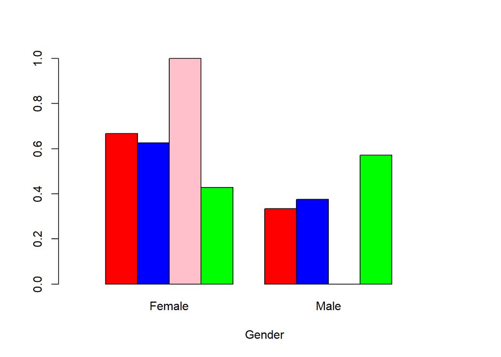

```r
barplot(prop.table(mg,1), width=0.25, xlim=c(0,3), ylim=c(0,1), xlab="Gender", legend=levels(mo), beside=T, col = c("red","blue", "pink","green")) # creating a bar chart of mg
```

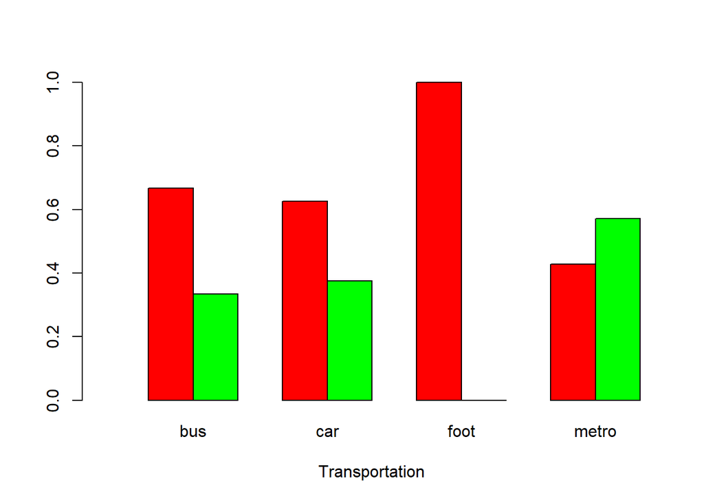

```r
mg = table(g,mo) # creating a contingency matrix of g and mo
barplot(prop.table(mg,2), width=0.25, xlim=c(0,3), ylim=c(0,1), xlab="Transportation", legend=levels(g), beside=T, col= c("red", "green")) # creating a bar chart of mg
```

## Histograms

`Histograms` are used to visualize the distribution of numerical data. Histograms are used to show the frequency of different values in a dataset. Histograms are used to visualize the distribution of numerical data.

```r
xo = c(10, 10, 5, 9, 7, 6,8,6,5,8, 10, 7, 7,8, 5, 6,4,7,9,7, 4,8, 10,10, 7,4,9,5,8,9) # creating a vector
table(xo) # creating a table of xo
```

```
## xo
##  4  5  6  7  8  9 10
##  3  4  3  6  5  4  5
```

```r
data.frame(xo) # creating a dataframe of xo
```

| xo |
| --- |
| 10 |
| 10 |
| 5 |
| 9 |
| 7 |
| 6 |
| 8 |
| 6 |
| 5 |
| 8 |

[output cut: 20 more lines]

```r
prop.table(table(xo)) # creating a table of xo
```

```
## xo
##         4         5         6         7         8         9        10
## 0.1000000 0.1333333 0.1000000 0.2000000 0.1666667 0.1333333 0.1666667
```

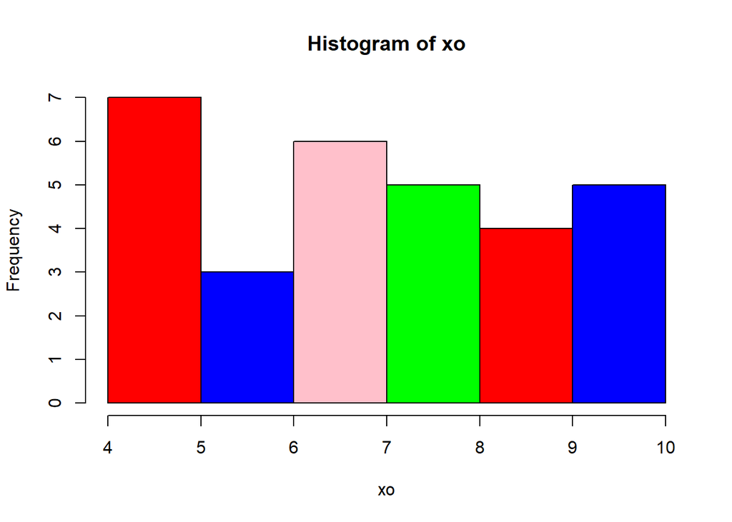

```r
#?prop.table


hist(xo, col = c("red","blue", "pink","green")) # creating a histogram of xo
```

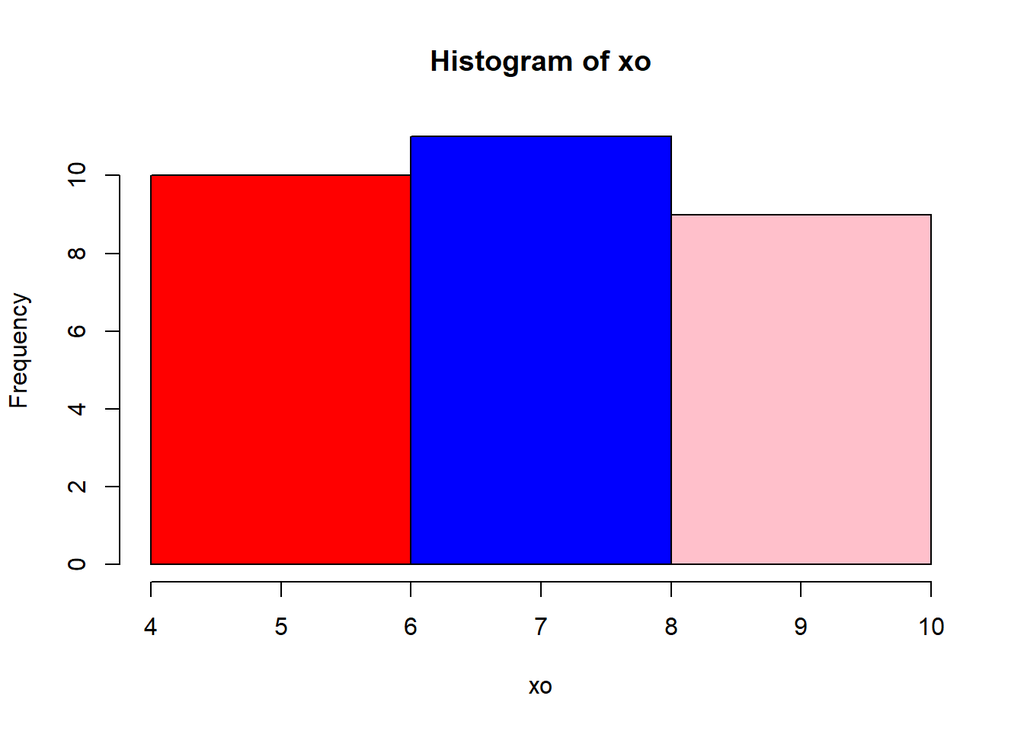

```r
hist(xo, nclass = 3, col = c("red","blue", "pink","green")) # creating a histogram of xo
```

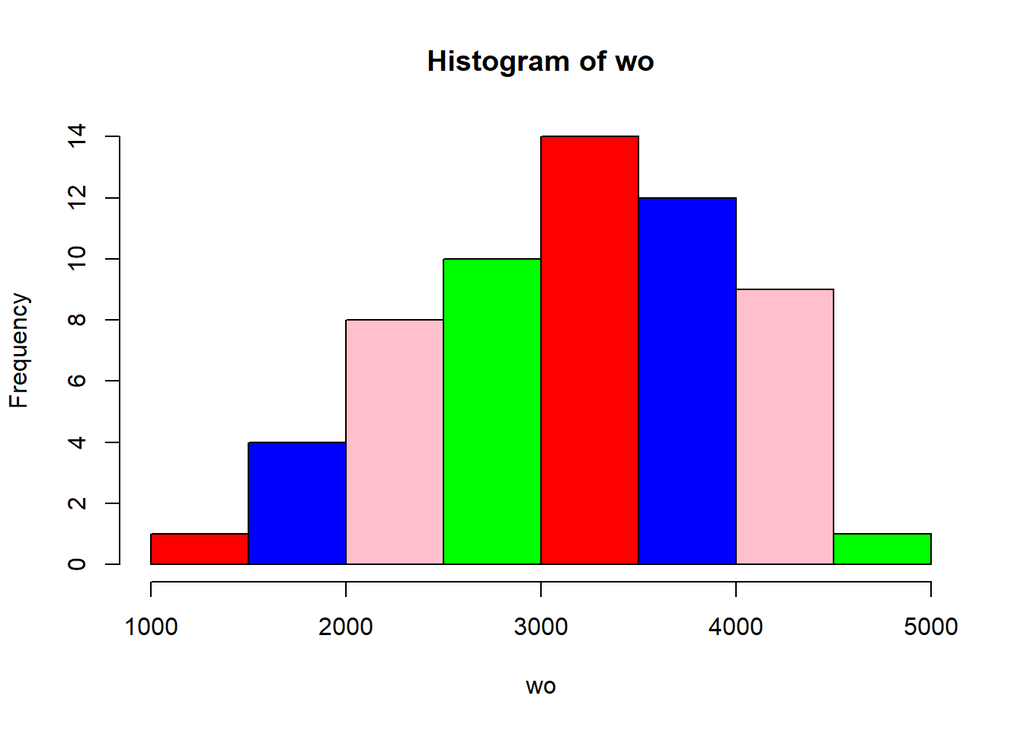

```r
wo = c (1950, 2090, 2700, 3350, 4200, 3720, 4400, 2980, 3850, 4550, 3050, 2350, 1850, 2820, 3670, 2950, 3750, 1850, 2420, 3150, 3000, 3470, 3920, 3100, 2400, 2900, 2650, 3450, 3650, 4020, 4450, 3120, 3660, 3070, 3550, 2020, 3500, 2500, 3780, 3940, 3540, 2800, 4450, 1950, 3020, 2800, 3500, 1480, 4495,2850, 3100, 2250,3300, 4100, 3220, 3600,2130, 4020, 4075) # creating a vector

hist(wo, col = c("red","blue", "pink","green")) # creating a histogram of wo
```

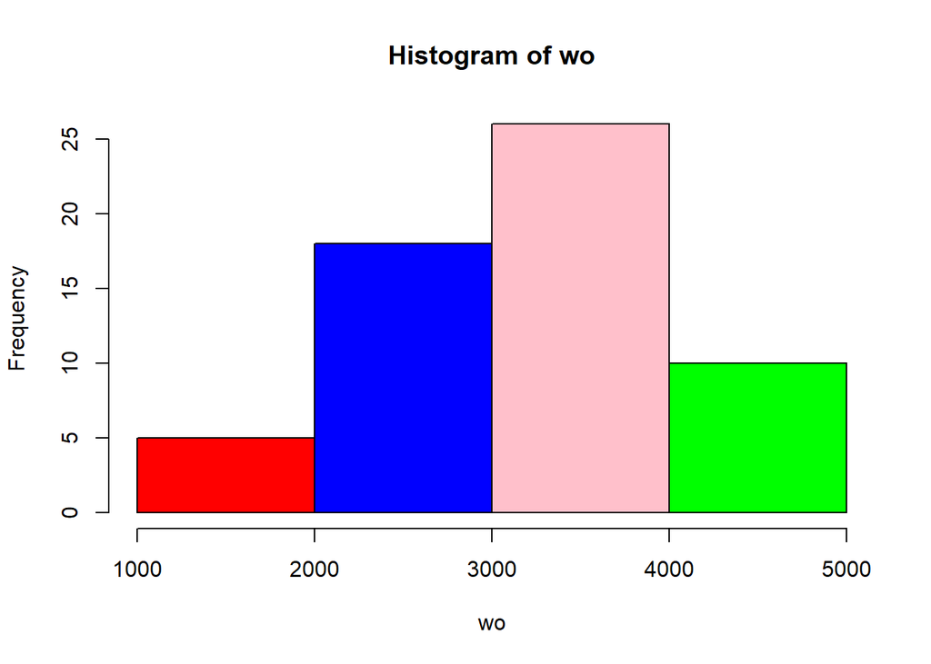

```r
hist(wo, nclass=4, col = c("red","blue", "pink","green")) # creating a histogram of wo
```

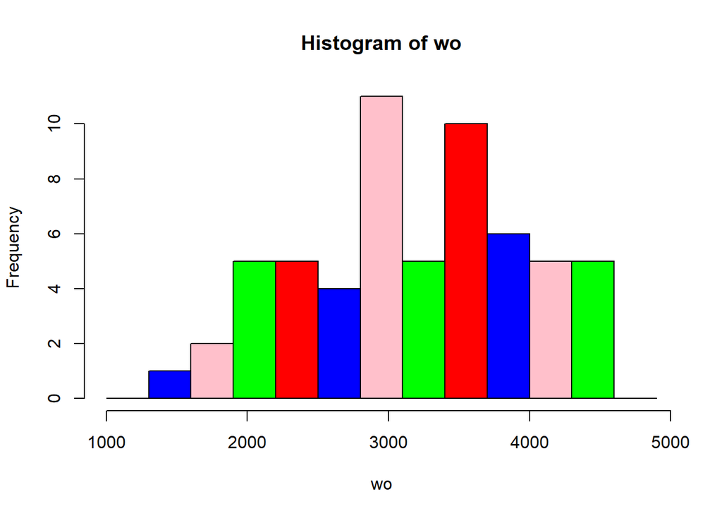

```r
hist(wo, breaks= seq(from = 1000, to=5000, by=300), col = c("red","blue", "pink","green")) # creating a histogram of wo
```

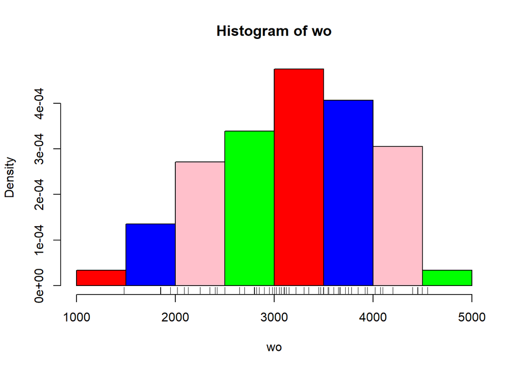

```r
hist(wo, probability=T, col = c("red","blue", "pink","green")) # creating a histogram of wo
rug(jitter(wo)) # creating a histogram of wo
```

## Frequency Polygon

`Frequency polygons` are used to visualize the distribution of numerical data. Frequency polygons are used to show the frequency of different values in a dataset. Frequency polygons are used to visualize the distribution of numerical data.

```r
temp = hist(wo, col = c("red","blue", "purple","green")) # creating a histogram of wo
temp
```

```
## $breaks
## [1] 1000 1500 2000 2500 3000 3500 4000 4500 5000
##
## $counts
## [1]  1  4  8 10 14 12  9  1
##
## $density
## [1] 3.389831e-05 1.355932e-04 2.711864e-04 3.389831e-04 4.745763e-04
## [6] 4.067797e-04 3.050847e-04 3.389831e-05
##
## $mids
## [1] 1250 1750 2250 2750 3250 3750 4250 4750
##
## $xname
## [1] "wo"
##
## $equidist
## [1] TRUE
##
## attr(,"class")
## [1] "histogram"
```

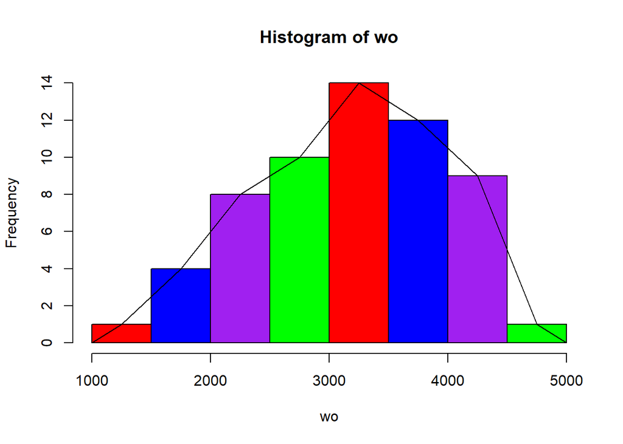

```r
lines(c(min(temp$breaks), (temp$mids),max(temp$breaks)), c(0,temp$counts,0),type="l") # creating a frequency polygon of wo
```

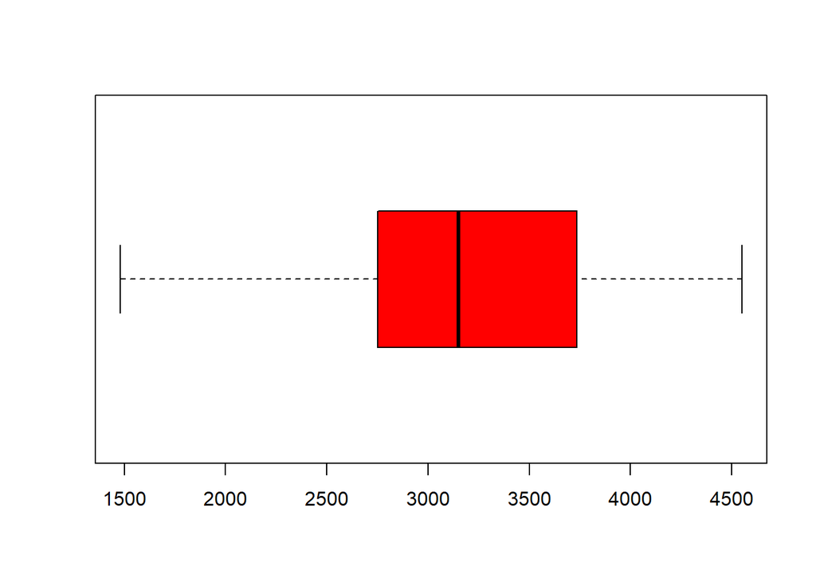

```r
boxplot(wo, horizontal = T, col = c("red")) # creating a boxplot of wo
```

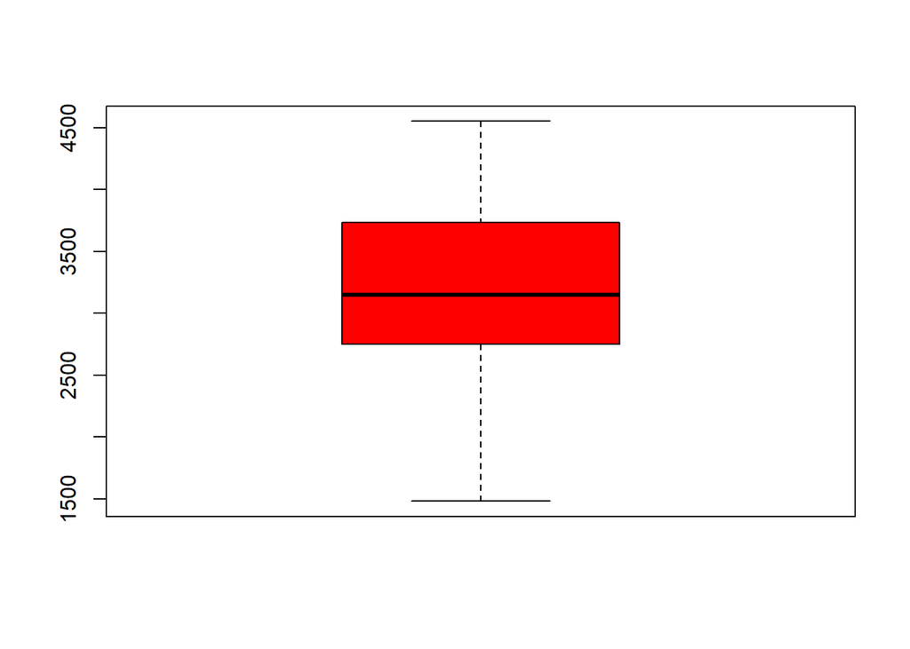

```r
boxplot(wo, vertical = T, col = c("red")) # creating a boxplot of wo
```

```r
fivenum(wo) # summary  of wo
```

```
## [1] 1480 2750 3150 3735 4550
```

```r
summary(wo) # summary of wo
```

```
##    Min. 1st Qu.  Median    Mean 3rd Qu.    Max.
##    1480    2750    3150    3195    3735    4550
```

```r
#?fivenum
```

```r
w1 = c(1950, 2090, 2700, 3350, 4200, 3720, 4400, 2980, 3850, 4550, 3050, 2350,1850, 2820, 3670, 2950, 3750, 1850, 2420,3150, 3000, 3470, 3920, 3100, 2400, 2900, 2650, 3450, 3650, 4020) # creating a vector of w1

fivenum(w1) # summary of w1
```

```
## [1] 1850 2650 3075 3720 4550
```

```r
w2 = c(4450, 3120, 3660, 3070, 3550, 2020, 3500, 2500, 3780, 3940, 3340, 2800, 2850, 4450, 1950,3020,2800,3500,1480,4495,2850,3100,2250,3300,4100,3220,3600,2130,4020,4075) # creating a vector of w2

fivenum(w2) # summary of w2
```

```
## [1] 1480 2800 3260 3780 4495
```

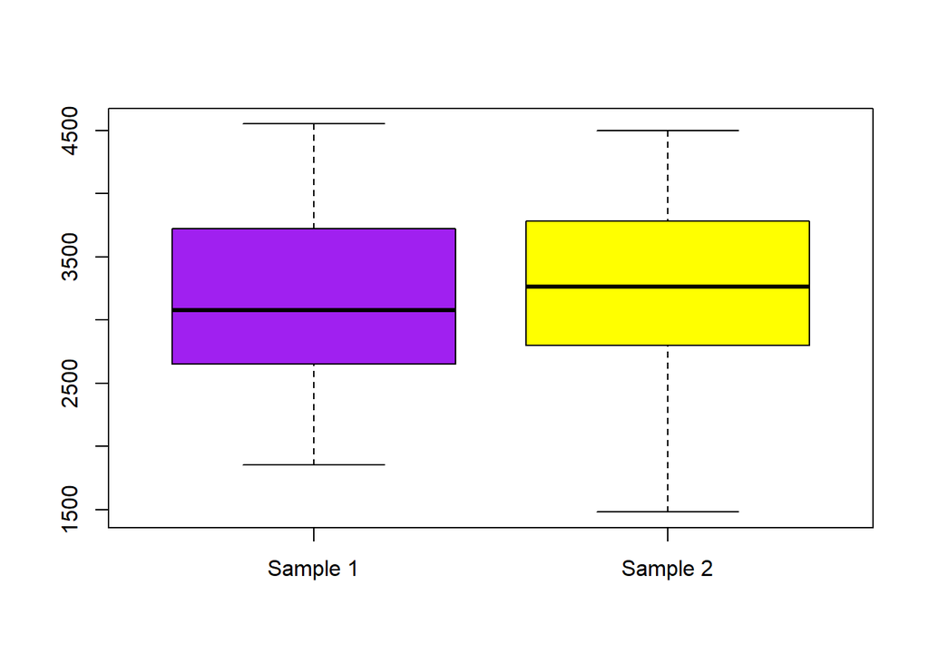

```r
boxplot(w1, w2, names = c("Sample 1", "Sample 2"), col = c("purple", "yellow" )) # creating a boxplot of w1 and w2
```

# Classification and Prediction

`Classification and prediction` are important tasks in data analysis. Classification is the process of categorizing data into different classes. Prediction is the process of predicting the value of a target variable based on the values of other variables. `Classification` and `prediction` are used to make decisions based on data.

```r
computeCost <- function(X, y, th){
m <- length(y)
return(1/(2*m) * sum((X%*%th - y)^2))
}

computeCost(5,6,7) # computing the cost of 5,6,7
```

```
## [1] 420.5
```

```r
grad_desc <- function(X, y, theta,alpha, lambda, num_iters){
m <- length(y)
F_history <- c(rep(0, num_iters)) # creating a vector of zeros

for (iter in c(1:num_iters)){
  temp <- vector()
  temp <- theta * (1 - ((alpha*lambda)/m)) - alpha*(1/m) *   (t(X) %*% (X %*% theta - y))
  theta <- temp
  F_history[iter] <- computeCost(X, y, theta)
}
print(F_history[num_iters])
return(list("theta" = theta, "F_history" = F_history))
}

grad_desc(2,3,5,0.1,7.5,2) # computing the output
```

```
## [1] 1.540012
```

```
## $theta
##        [,1]
## [1,] 0.6225
##
## $F_history
## [1] 5.445000 1.540012
```

# Clustering

Clustering is a technique used to group similar data points together. Clustering is used to identify patterns and relationships in data. Clustering is used to group data points into clusters based on their similarity. Clustering is used to analyze and explore data.

`kmeans` is a popular clustering algorithm that is used to group data points into k clusters. kmeans is an unsupervised learning algorithm that is used to identify patterns and relationships in data. kmeans is used to group data points into clusters based on their similarity.

```r
iris_new <- iris # assigning iris to iris_new
### iris_new
iris_new$Species <- NULL # assigning the species class to null
kc <- kmeans(iris_new, 3) # creating a kmeans of iris_new
table(iris$Species, kc$cluster) # creating a table of iris and kc
```

```
##
##               1  2  3
##   setosa      0  0 50
##   versicolor  2 48  0
##   virginica  36 14  0
```

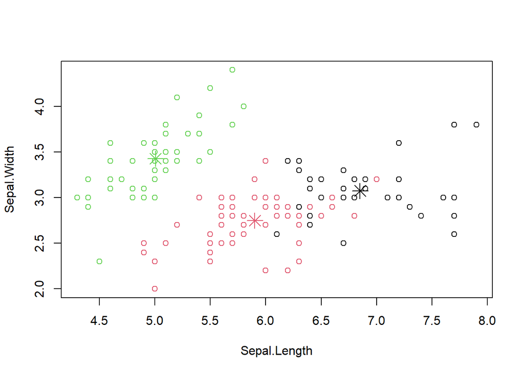

```r
plot(iris_new[c("Sepal.Length", "Sepal.Width")], col = kc$cluster) # visualizing the  iris datasets
points(kc$centers[,c("Sepal.Length","Sepal.Width")], col = 1:3, pch = 8, cex = 2)
```

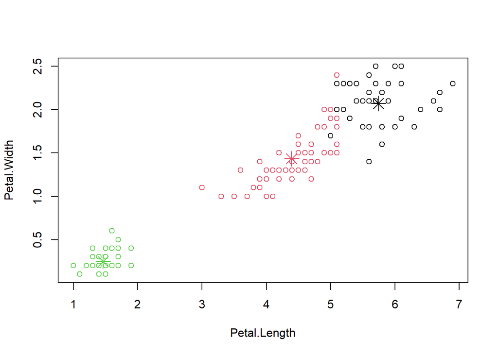

```r
plot(iris_new[c("Petal.Length", "Petal.Width")], col = kc$cluster) # visualizing the iris dataset
points(kc$centers[,c("Petal.Length","Petal.Width")], col = 1:3, pch = 8, cex = 2)
```

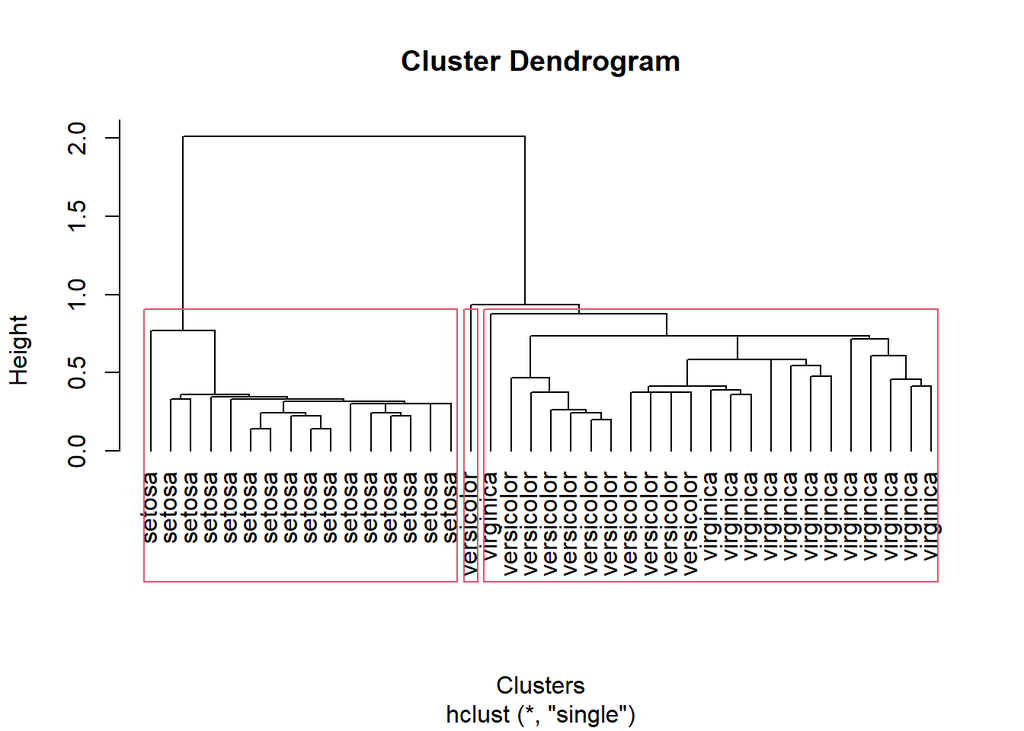

```r
data(iris) # importing the iris dataset
set.seed(500) # setting the seed to 500 to avoid randomness
idx <- sample(1:dim(iris)[1], 40) # sampling the iris dataset
iris_Sample <- iris[idx,] # assigning the sampled iris dataset to iris_Sample
iris_Sample$Species <- NULL # assigning the species class to null
hc <- hclust(dist(iris_Sample), method = "single") # creating a hclust of iris_Sample

plot(hc, hang = -1, labels = iris$Species[idx], xlab = "Clusters") # visualizing the iris dataset
rect.hclust(hc, 3) # creating a rect.hclust of 3
```

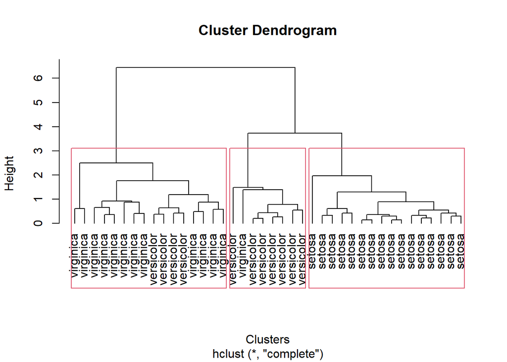

```r
hc <- hclust(dist(iris_Sample),method = "complete") # creating a hclust of iris_Sample
plot(hc, hang = -1, labels = iris$Species[idx], xlab = "Clusters") # visualing the iris dataset
rect.hclust(hc, 3) # creating a rect.hclust of 3
```

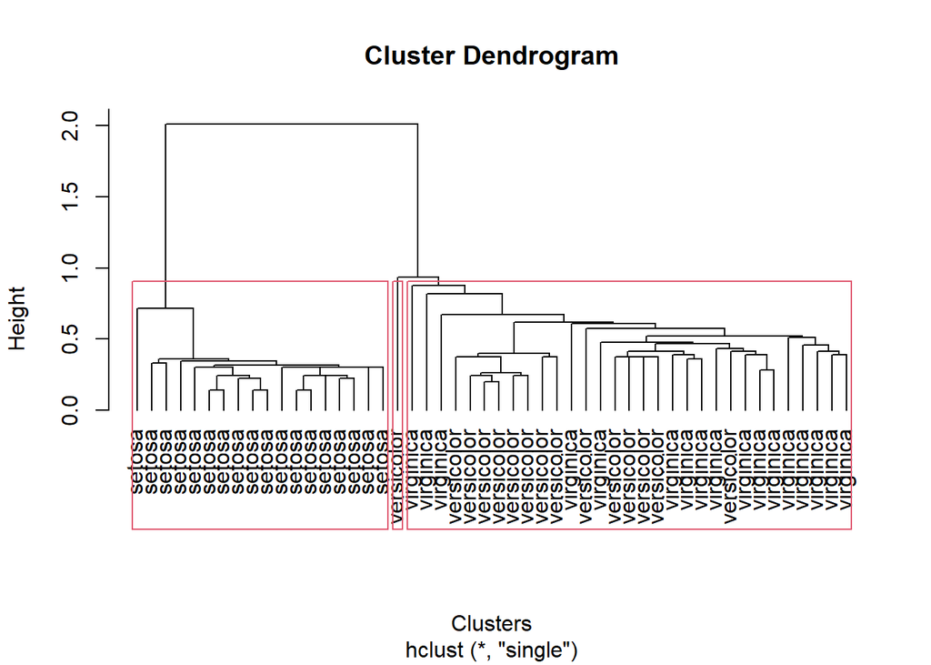

```r
data(iris)
set.seed(500)
idx <- sample(1:dim(iris)[1], 50)
iris_Sample <- iris[idx,]
iris_Sample$Species <- NULL
hc <- hclust(dist(iris_Sample), method = "single")
plot(hc, hang = -1, labels = iris$Species[idx], xlab = "Clusters")
rect.hclust(hc, 3)
```

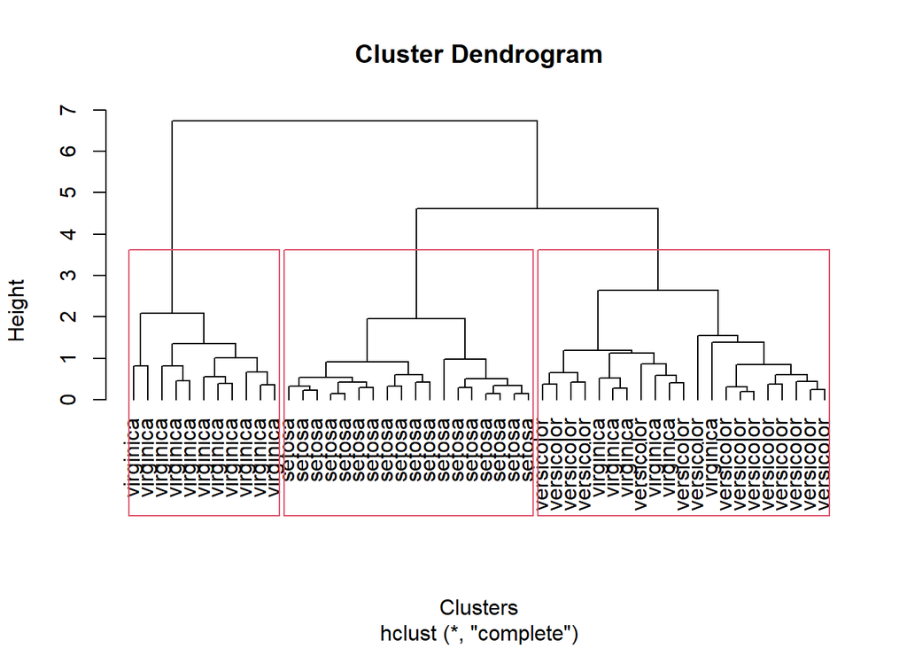

```r
hc <- hclust(dist(iris_Sample),method = "complete")
plot(hc, hang = -1, labels = iris$Species[idx], xlab = "Clusters")
rect.hclust(hc, 3)
```

```r
tr = trees # assigning trees to tr

as.data.frame(tr) # converting tr to a dataframe
```

| Girth | Height | Volume |
| --- | --- | --- |
| 8.3 | 70 | 10.3 |
| 8.6 | 65 | 10.3 |
| 8.8 | 63 | 10.2 |
| 10.5 | 72 | 16.4 |
| 10.7 | 81 | 18.8 |
| 10.8 | 83 | 19.7 |
| 11.0 | 66 | 15.6 |
| 11.0 | 75 | 18.2 |
| 11.1 | 80 | 22.6 |
| 11.2 | 75 | 19.9 |

[output cut: 21 more lines]

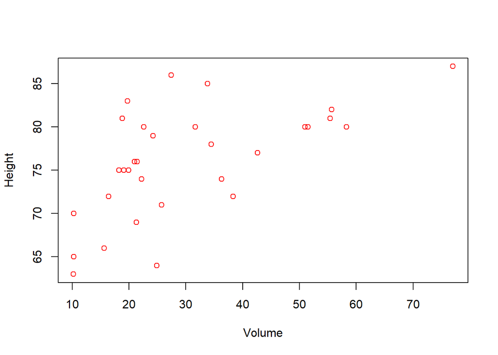

```r
plot(tr[c("Volume","Height")], col = "red") # visualizing the trees dataset
```

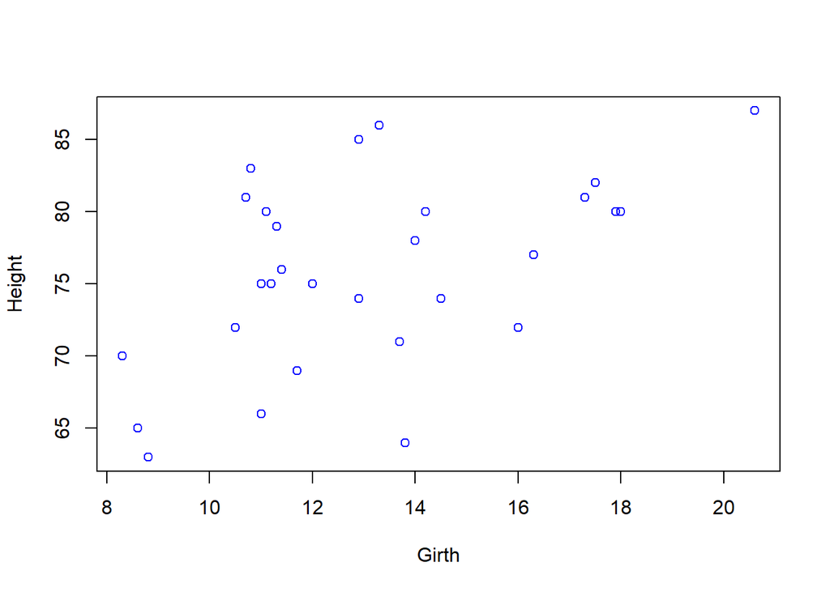

```r
plot(tr[c("Girth","Height")], col = "blue" ) # visualizing the trees dataset
```

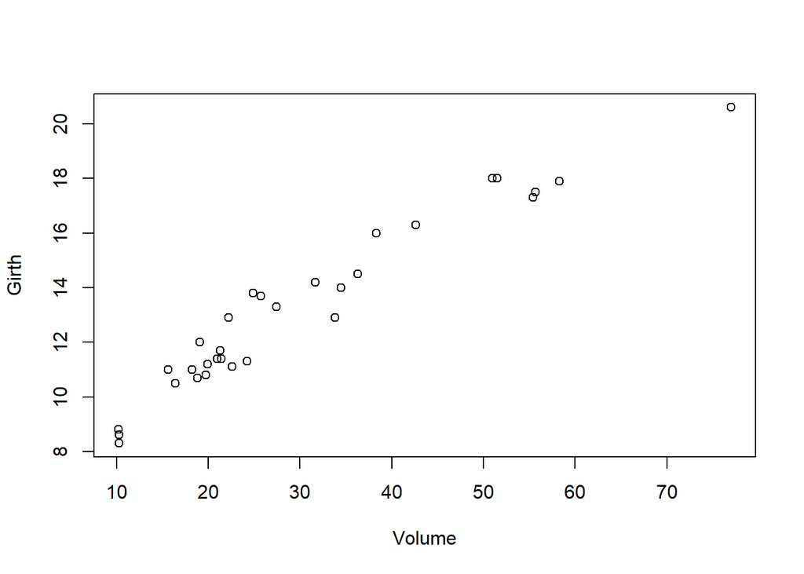

```r
plot(tr[c("Volume","Girth")], col = "black" ) # visualizing the trees dataset
```

```r
ca = cars # assigning cars to ca

as.data.frame(ca) # converting ca to a dataframe
```

| speed | dist |
| --- | --- |
| 4 | 2 |
| 4 | 10 |
| 7 | 4 |
| 7 | 22 |
| 8 | 16 |
| 9 | 10 |
| 10 | 18 |
| 10 | 26 |
| 10 | 34 |
| 11 | 17 |

[output cut: 40 more lines]

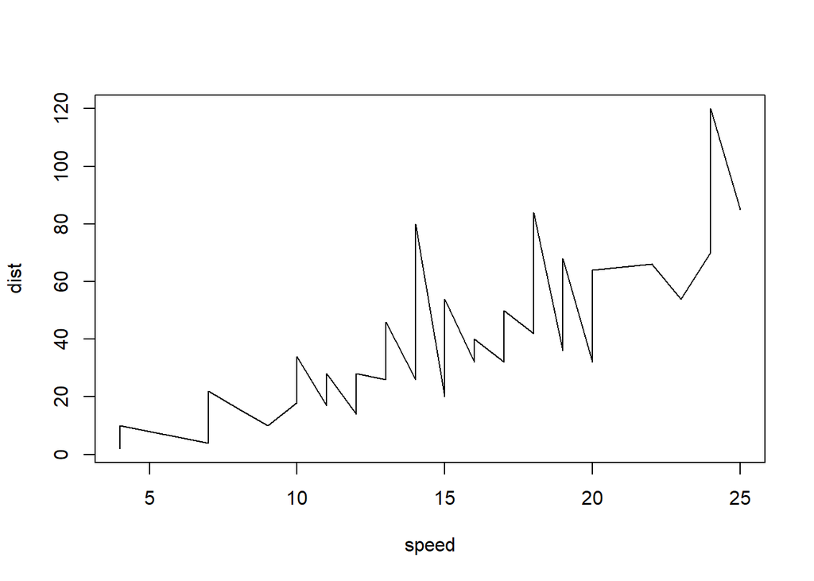

```r
plot(ca[c("speed","dist")], type = "l") # visualizing the cars dataset
```

```r
pre = pressure # assigning pressure to pre

as.data.frame(pre) # converting pre to a dataframe
```

| temperature | pressure |
| --- | --- |
| 0 | 0.0002 |
| 20 | 0.0012 |
| 40 | 0.0060 |
| 60 | 0.0300 |
| 80 | 0.0900 |
| 100 | 0.2700 |
| 120 | 0.7500 |
| 140 | 1.8500 |
| 160 | 4.2000 |
| 180 | 8.8000 |

[output cut: 9 more lines]

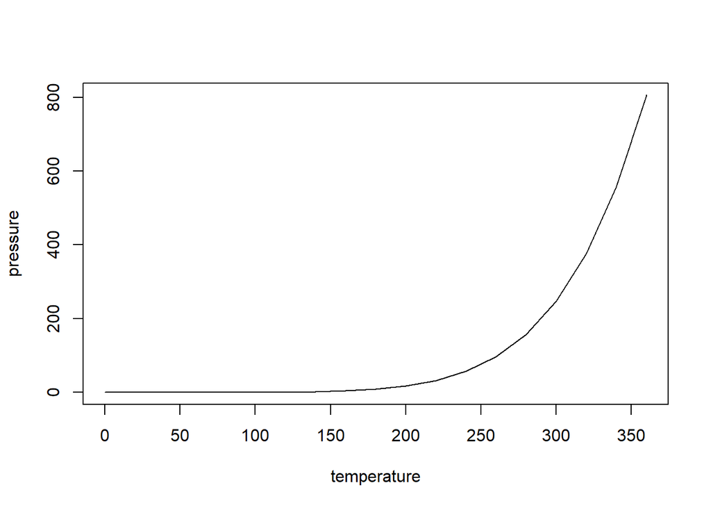

```r
plot(pre[c("temperature","pressure")], type="l") # visualizing the pressure dataset
```

```r
cab = CO2 # assigning CO2 to cab

as.data.frame(cab) # converting cab to a dataframe
```

|  | Plant | Type | Treatment | conc | uptake |
| --- | --- | --- | --- | --- | --- |
| 1 | Qn1 | Quebec | nonchilled | 95 | 16.0 |
| 2 | Qn1 | Quebec | nonchilled | 175 | 30.4 |
| 3 | Qn1 | Quebec | nonchilled | 250 | 34.8 |
| 4 | Qn1 | Quebec | nonchilled | 350 | 37.2 |
| 5 | Qn1 | Quebec | nonchilled | 500 | 35.3 |
| 6 | Qn1 | Quebec | nonchilled | 675 | 39.2 |
| 7 | Qn1 | Quebec | nonchilled | 1000 | 39.7 |
| 8 | Qn2 | Quebec | nonchilled | 95 | 13.6 |
| 9 | Qn2 | Quebec | nonchilled | 175 | 27.3 |
| 10 | Qn2 | Quebec | nonchilled | 250 | 37.1 |

[output cut: 74 more lines]

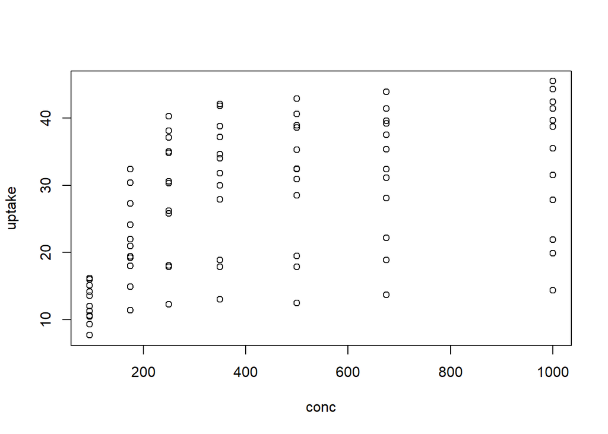

```r
plot(cab[c("conc","uptake")]) # visualizing the CO2 dataset
```